# Structural equation modeling

Sandra M Durán

December 22, 2017

**Lesson on structural equation modeling (SEM) in R- Dec 7 2017**

In this script, I cover some basics of SEM in R, specifically SEM with observed variables. The script and slides focus on developing models, and understanding model construction.

This script was developed using some online tutorials and R-code available from Dr. Jarret Byrnes and Bill Shipley. To get help in other types of SEM, and use of other packages (e.g., lavaan) check the references and links below:

- [Jarret Byrnes tutorials](http://jarrettbyrnes.info/sem.shtml)
- [Shipley 2009. Confirmatory path analysis paper](http://onlinelibrary.wiley.com/doi/10.1890/08-1034.1/abstract) Usefult to perform path analysis with categorical or presence/absence data)
- Shipley, B. 2016. Cause and correlation in biology: a user’s guide to path analysis, structural equations and causal inference with R. Cambridge University Press.
- Grace, James B. Structural equation modeling and natural systems. Cambridge University Press, 2006.
- [Piecewise SEM package](https://jonlefcheck.net/2014/07/06/piecewise-structural-equation-modeling-in-ecological-research/) Useful to learn model specification and run SEMs with no-continuous data.

**Basic definitions of SEM**

- [Review attached slides 1-5 for basic definitions of SEM](https://github.com/smduranm/EEB_R_workshops/R_workshop_SEM.pdf)

```r
#Set your working directory
setwd("C:/Users/smduranm/Documents/R-lessons/EEB_R_workshops/data")


#uploading required packages
library(lavaan)
library(car)
library(QuantPsyc)
library(ggm)
```

```r
library(semPlot)
library(devtools)

#Load your data file
keeley<-read.csv("./Keeley_rawdata.csv")

#check the data
head(keeley)
```

```
##   distance elev  abiotic age   hetero firesev     cover rich
## 1 53.40900 1225 60.67103  40 0.757065    3.50 1.0387974   51
## 2 37.03745   60 40.94291  25 0.491340    4.05 0.4775924   31
## 3 53.69565  200 50.98805  15 0.844485    2.60 0.9489357   71
## 4 53.69565  200 61.15633  15 0.690847    2.90 1.1949002   64
## 5 51.95985  970 46.66807  23 0.545628    4.30 1.2981890   68
## 6 51.95985  970 39.82357  24 0.652895    4.00 1.1734866   34
```

```r
summary(keeley) #missing data?
```

```
##     distance          elev           abiotic           age
##  Min.   :37.04   Min.   :  60.0   Min.   :32.59   Min.   : 3.00
##  1st Qu.:39.46   1st Qu.: 202.5   1st Qu.:43.81   1st Qu.:15.00
##  Median :51.77   Median : 400.0   Median :48.04   Median :25.00
##  Mean   :49.23   Mean   : 424.7   Mean   :49.24   Mean   :25.57
##  3rd Qu.:58.40   3rd Qu.: 630.0   3rd Qu.:54.90   3rd Qu.:35.00
##  Max.   :60.72   Max.   :1225.0   Max.   :70.46   Max.   :60.00
##      hetero          firesev          cover              rich
##  Min.   :0.3842   Min.   :1.200   Min.   :0.05558   Min.   :15.00
##  1st Qu.:0.6246   1st Qu.:3.700   1st Qu.:0.48769   1st Qu.:37.00
##  Median :0.6843   Median :4.300   Median :0.63712   Median :50.00
##  Mean   :0.6833   Mean   :4.565   Mean   :0.69123   Mean   :49.23
##  3rd Qu.:0.7684   3rd Qu.:5.550   3rd Qu.:0.91468   3rd Qu.:62.00
##  Max.   :0.8779   Max.   :9.200   Max.   :1.53541   Max.   :85.00
```

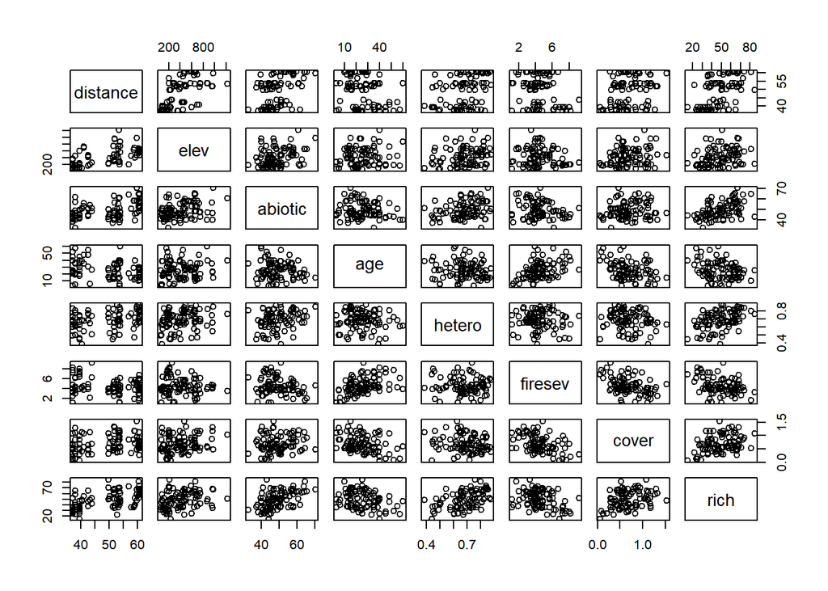

```r
#Analyze the relationship between variables
pairs(keeley) #linear relationships, normal dist, outliers
```

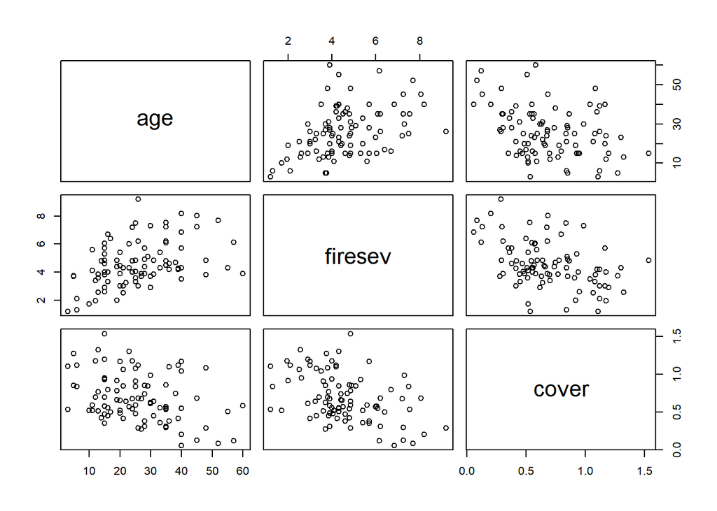

```r
myvars <- keeley[, c(4,6,7)]
pairs(myvars)
```

```r
#Our model for today
names(keeley)
```

```
## [1] "distance" "elev"     "abiotic"  "age"      "hetero"   "firesev"
## [7] "cover"    "rich"
```

```r
attach(keeley)

#regression syntax versus lavaan
aLM<-lm(cover ~ age, data=keeley)

#F Table
library(car)
Anova(aLM)
```

```
## Anova Table (Type II tests)
##
## Response: cover
##           Sum Sq Df F value    Pr(>F)
## age       1.0998  1  12.318 0.0007097 ***
## Residuals 7.8570 88
## ---
## Signif. codes:  0 '***' 0.001 '**' 0.01 '*' 0.05 '.' 0.1 ' ' 1
```

```r
#getting coefficients
summary(aLM)
```

```
##
## Call:
## lm(formula = cover ~ age, data = keeley)
##
## Residuals:
##      Min       1Q   Median       3Q      Max
## -0.50798 -0.24998 -0.03638  0.18407  0.75070
##
## Coefficients:
##              Estimate Std. Error t value Pr(>|t|)
## (Intercept)  0.917395   0.071726   12.79  < 2e-16 ***
## age         -0.008846   0.002520   -3.51  0.00071 ***
## ---
## Signif. codes:  0 '***' 0.001 '**' 0.01 '*' 0.05 '.' 0.1 ' ' 1
##
## Residual standard error: 0.2988 on 88 degrees of freedom
## Multiple R-squared:  0.1228, Adjusted R-squared:  0.1128
## F-statistic: 12.32 on 1 and 88 DF,  p-value: 0.0007097
```

```r
#standardized coefficients
coef(aLM)[2]*sd(keeley$age)/sd(keeley$cover)
```

```
##        age
## -0.3504073
```

```r
#standardized coefficients 2
library(QuantPsyc)
lm.beta(aLM)
```

```
##        age
## -0.3504073
```

```r
#####
#Multiple Regression & SEM
#####

aLM2<-lm(cover ~ age+firesev, data=keeley)

#what to include...
Anova(aLM2)
```

```
## Anova Table (Type II tests)
##
## Response: cover
##           Sum Sq Df F value   Pr(>F)
## age       0.2606  1  3.2466 0.075034 .
## firesev   0.8724  1 10.8667 0.001418 **
## Residuals 6.9846 87
## ---
## Signif. codes:  0 '***' 0.001 '**' 0.01 '*' 0.05 '.' 0.1 ' ' 1
```

```r
#difference with anova!
anova(aLM2)
```

```
## Analysis of Variance Table
##
## Response: cover
##           Df Sum Sq Mean Sq F value    Pr(>F)
## age        1 1.0998 1.09976  13.699 0.0003757 ***
## firesev    1 0.8724 0.87241  10.867 0.0014185 **
## Residuals 87 6.9846 0.08028
## ---
## Signif. codes:  0 '***' 0.001 '**' 0.01 '*' 0.05 '.' 0.1 ' ' 1
```

```r
#standardized coefs
cor(keeley$age, keeley$firesev)
```

```
## [1] 0.4538654
```

```r
summary(aLM2)$r.squared
```

```
## [1] 0.2201874
```

```r
lm.beta(aLM2)
```

```
##        age    firesev
## -0.1914431 -0.3502452
```

```r
#finish the sem
aLM3<-lm(firesev ~ age, data=keeley)
Anova(aLM3)
```

```
## Anova Table (Type II tests)
##
## Response: firesev
##            Sum Sq Df F value    Pr(>F)
## age        50.055  1   22.83 7.028e-06 ***
## Residuals 192.937 88
## ---
## Signif. codes:  0 '***' 0.001 '**' 0.01 '*' 0.05 '.' 0.1 ' ' 1
```

```r
summary(aLM3)$r.squared
```

```
## [1] 0.2059938
```

```r
lm.beta(aLM3)
```

```
##       age
## 0.4538654
```

```r
##############################
#Moving to SEM
##############################

#Refit the new cover relationship
fullMedLM<-lm(cover ~ firesev, data=keeley)
summary(fullMedLM)$r.squared
```

```
## [1] 0.1910867
```

```r
lm.beta(fullMedLM)
```

```
##    firesev
## -0.4371346
```

```r
keeley$fireCoverResiduals<-residuals(fullMedLM)
residLM<-lm(fireCoverResiduals ~ age, data=keeley)
Anova(residLM)
```

```
## Anova Table (Type II tests)
##
## Response: fireCoverResiduals
##           Sum Sq Df F value Pr(>F)
## age       0.2070  1  2.5876 0.1113
## Residuals 7.0383 88
```

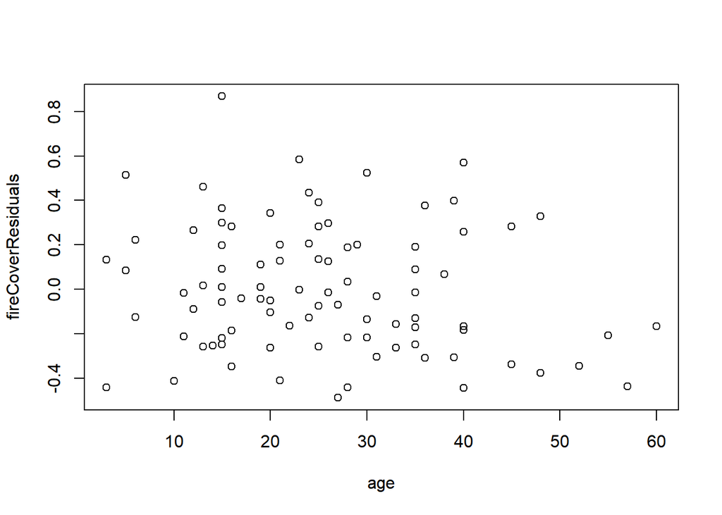

```r
plot(fireCoverResiduals ~ age, data=keeley)
```

```r
################################
### SEM for Exercise
################################

#fit the pieces
abioticLM <- lm(abiotic ~ distance, data=keeley)
heteroLM <- lm(hetero ~ distance, data=keeley)
richnessLM <- lm(rich ~ abiotic + distance + hetero, data=keeley)

#evaluate the pieces
Anova(abioticLM)
```

```
## Anova Table (Type II tests)
##
## Response: abiotic
##           Sum Sq Df F value    Pr(>F)
## distance  1109.2  1  23.582 5.158e-06 ***
## Residuals 4139.0 88
## ---
## Signif. codes:  0 '***' 0.001 '**' 0.01 '*' 0.05 '.' 0.1 ' ' 1
```

```r
Anova(heteroLM)
```

```
## Anova Table (Type II tests)
##
## Response: hetero
##            Sum Sq Df F value    Pr(>F)
## distance  0.14045  1  11.967 0.0008371 ***
## Residuals 1.03285 88
## ---
## Signif. codes:  0 '***' 0.001 '**' 0.01 '*' 0.05 '.' 0.1 ' ' 1
```

```r
Anova(richnessLM)
```

```
## Anova Table (Type II tests)
##
## Response: rich
##            Sum Sq Df F value    Pr(>F)
## abiotic    1110.8  1  8.8765  0.003754 **
## distance   2096.8  1 16.7553 9.564e-05 ***
## hetero     1129.3  1  9.0243  0.003489 **
## Residuals 10762.3 86
## ---
## Signif. codes:  0 '***' 0.001 '**' 0.01 '*' 0.05 '.' 0.1 ' ' 1
```

```r
#standardized coefficients & r^2
lm.beta(abioticLM)
```

```
##  distance
## 0.4597233
```

```r
lm.beta(heteroLM)
```

```
##  distance
## 0.3459875
```

```r
lm.beta(richnessLM)
```

```
##   abiotic  distance    hetero
## 0.2660206 0.3743419 0.2538814
```

```r
summary(abioticLM)$r.squared
```

```
## [1] 0.2113455
```

```r
summary(heteroLM)$r.squared
```

```
## [1] 0.1197074
```

```r
summary(richnessLM)$r.squared
```

```
## [1] 0.4700472
```

```r
#####
#Evaluate Mediation
richnessLM2 <- lm(rich ~ abiotic  + hetero, data=keeley)
summary(richnessLM2)$r.squared
```

```
## [1] 0.3667967
```

```r
lm.beta(richnessLM2)
```

```
##   abiotic    hetero
## 0.4135769 0.3425788
```

```r
keeley$richnessResidual<-residuals(richnessLM2)
richResidLM<-lm(richnessResidual ~ distance, data=keeley)
Anova(richResidLM)
```

```
## Anova Table (Type II tests)
##
## Response: richnessResidual
##           Sum Sq Df F value    Pr(>F)
## distance    1545  1  12.016 0.0008177 ***
## Residuals  11314 88
## ---
## Signif. codes:  0 '***' 0.001 '**' 0.01 '*' 0.05 '.' 0.1 ' ' 1
```

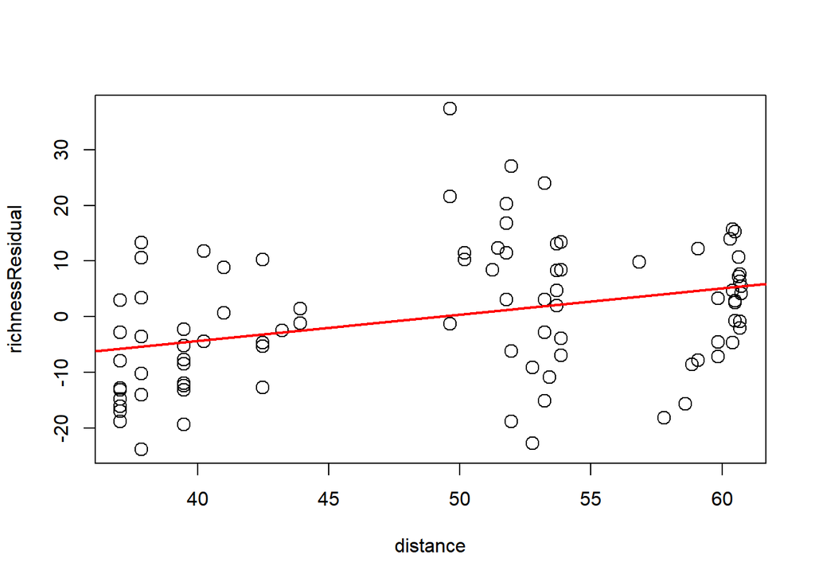

[figure not shown]

```r
#plot result
plot(richnessResidual ~ distance, data=keeley, cex=1.5)
abline(richResidLM, col="red", lwd=2)
```